# EMPLOYEE TURNOVER

## 6.1 Exploring the Data

We read the data from a csv file provided. You can download the data from this [link](https://raw.githubusercontent.com/Karuitha/data_projects/master/employee_turnover/data/employee_churn_data.csv) or copy and paste the following web address https://raw.githubusercontent.com/Karuitha/data_projects/master/employee_turnover/data/employee_churn_data.csv.

```r
my_col_names <- c("department", "promoted", "review", "projects", "salary", "tenure", "satisfaction", "bonus", "avg_hrs_month", "left")

df <- fread('./data/employee_churn_data.csv') %>%

  mutate(left = factor(left, levels = c("yes", "no")))

head(df) %>%

  kbl(., booktabs = TRUE,

      caption = "First Six Rows of the HR Data") %>%

  kable_classic(full_width = TRUE, font_size = 12,

                bootstrap_options = "striped")
```

First Six Rows of the HR Data

| department | promoted | review | projects | salary | tenure | satisfaction | bonus | avg_hrs_month | left |
| --- | --- | --- | --- | --- | --- | --- | --- | --- | --- |
| operations | 0 | 0.5775687 | 3 | low | 5 | 0.6267590 | 0 | 180.8661 | no |
| operations | 0 | 0.7518997 | 3 | medium | 6 | 0.4436790 | 0 | 182.7081 | no |
| support | 0 | 0.7225484 | 3 | medium | 6 | 0.4468232 | 0 | 184.4161 | no |
| logistics | 0 | 0.6751583 | 4 | high | 8 | 0.4401387 | 0 | 188.7075 | no |
| sales | 0 | 0.6762032 | 3 | high | 5 | 0.5776074 | 1 | 179.8211 | no |
| IT | 0 | 0.6832063 | 2 | medium | 5 | 0.5652519 | 1 | 178.8419 | no |

We then examine the data, starting with missing values and possible duplicates.

```r
sapply(df, is.na) %>%

  colSums() %>%

  tibble(variables = names(df), missing = .) %>%

  arrange(desc(missing)) %>%

  kbl(., booktabs = TRUE,

      caption = "Missing Data") %>%

  kable_classic(full_width = TRUE, font_size = 12,

                bootstrap_options = "striped")
```

Missing Data

| variables | missing |
| --- | --- |
| department | 0 |
| promoted | 0 |
| review | 0 |
| projects | 0 |
| salary | 0 |
| tenure | 0 |
| satisfaction | 0 |
| bonus | 0 |
| avg_hrs_month | 0 |
| left | 0 |

```r
df %>%

  filter(duplicated(.))
```

```
## Empty data.table (0 rows and 10 cols): department,promoted,review,projects,salary,tenure...
```

The data set has no missing values and duplicated records.We next delve into the analysis.

1. There is a low prevalence of workers who left versus those that remain in the organisation. Prevalence can have impact on the generalizability of machine learning models. Hence, it is always good to ensure data balance by up sampling or down sampling the data.
2. There is an extremely strong correlation between `tenure` and `working hours per month`. The observation means that workers that have stayed longer in the organisation tend to put in more hours. The implication is that workers who remain in the organisation have a higher motivation to work.

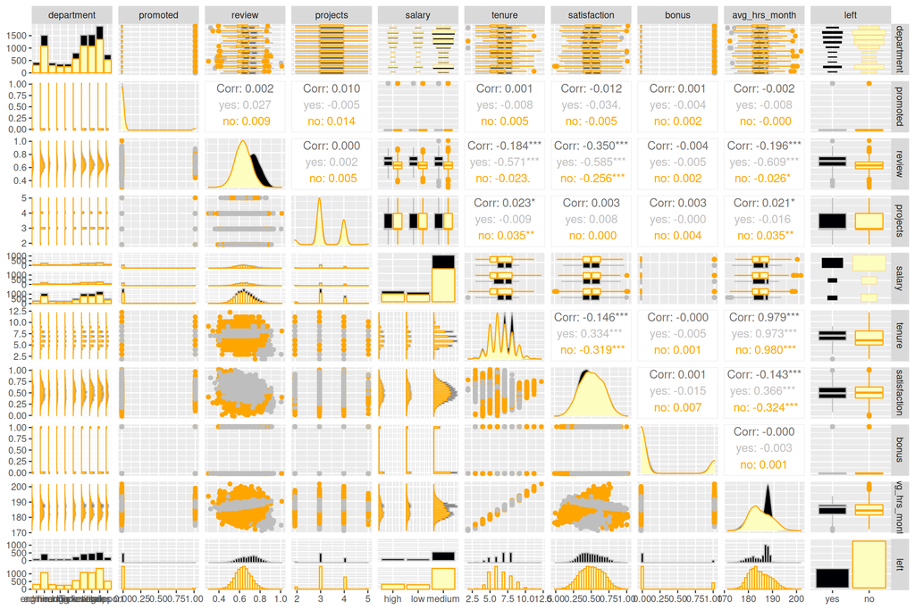

Visualisation of the Variables

```r
df %>%

  GGally::ggpairs(ggplot2::aes(col = left, fill = left)) +

  scale_color_manual(values = c("gray", "orange")) +

  scale_fill_viridis_d(option = "magma")
```

The charts below show the relationship between several variables with employee churn.

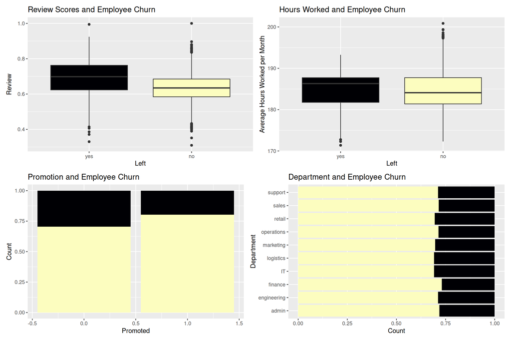

Visualisation of the Variables

```r
(df %>%

  ggplot(mapping = aes(x = left, y = review, fill = left)) +

  geom_boxplot(show.legend = FALSE) +

  scale_fill_viridis_d(option = "magma") +

  labs(x = "Left", y = "Review",

       title = "Review Scores and Employee Churn") +


df %>%

  ggplot(mapping = aes(x = left, y = avg_hrs_month,

                       fill = left)) +

  geom_boxplot(show.legend = FALSE) +

  scale_fill_viridis_d(option = "magma") +

  labs(x = "Left", y = "Average Hours Worked per Month",

       title = "Hours Worked and Employee Churn")) /



(df %>%

  ggplot(mapping = aes(x = promoted, y = ..count..)) +

  geom_bar(aes(fill = factor(left)),

           position = "fill", show.legend = FALSE) +

  scale_fill_viridis_d(option = "magma") +

  labs(x = "Promoted", y = "Count",

       title = "Promotion and Employee Churn") +


df %>%

  ggplot(mapping = aes(x = department, y = ..count..)) +

  geom_bar(aes(fill = factor(left)),

           position = "fill", show.legend = FALSE) +

  scale_fill_viridis_d(option = "magma") +

  labs(x = "Department", y = "Count",

       title = "Department and Employee Churn") +

  coord_flip())
```

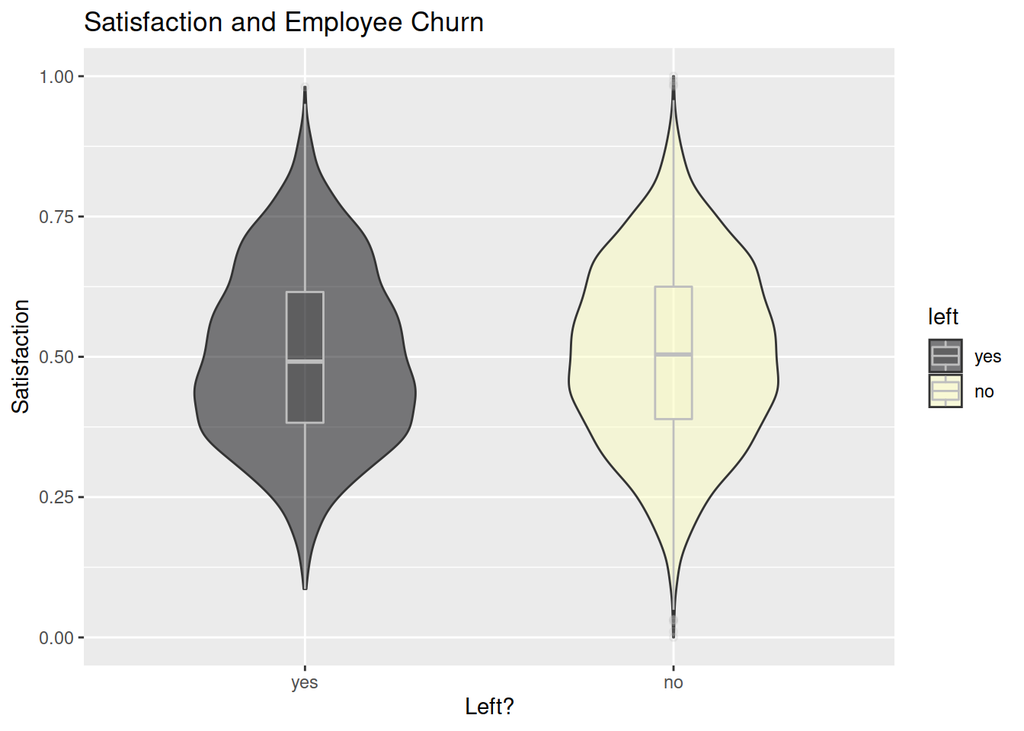

```r
df %>%

  ggplot(mapping = aes(x = left,

                       y = satisfaction,

                       fill = left)) +

  geom_violin(width=0.6) +

    geom_boxplot(width=0.1, color="grey", alpha=0.2) +

  scale_fill_viridis_d(option = "magma", alpha = 0.5) +

  labs(x = "Left?", y = "Satisfaction",

       title = "Satisfaction and Employee Churn")
```

## 6.2 Summary Statistics

In this section, We summarise the data and present the correlation matrix.

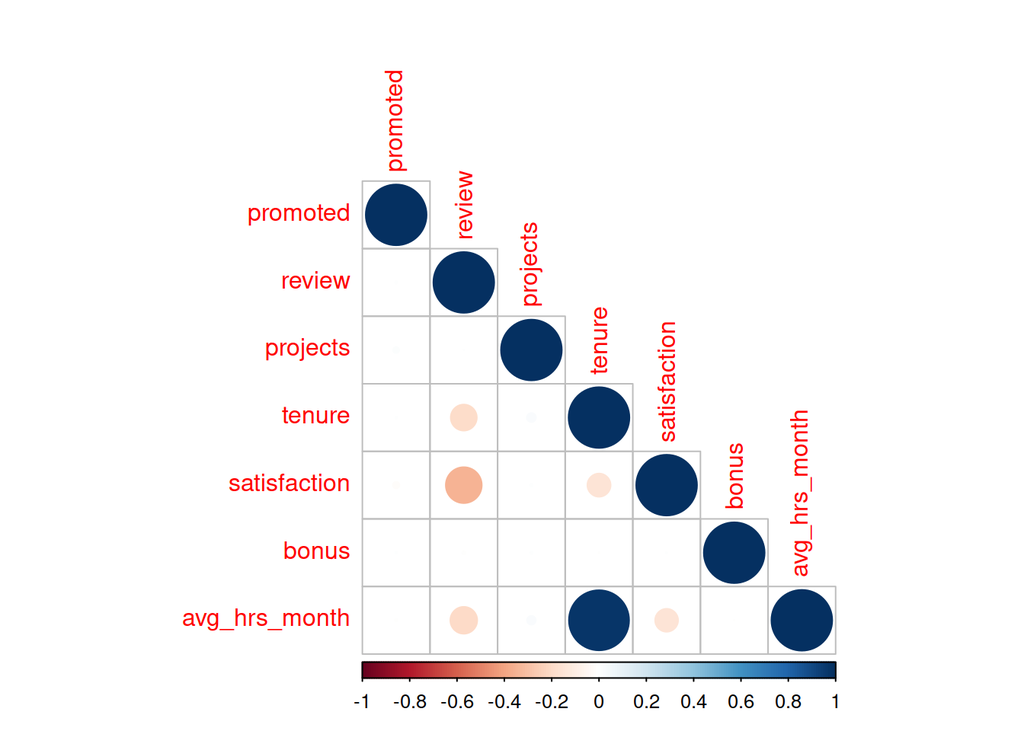

```r
df %>%

  select(where(is.numeric)) %>%

  cor() %>%

  corrplot(type = "lower")
```

```r
df %>%

  select(where(is.numeric)) %>%

  skimr::skim_without_charts() %>%

  select(-n_missing, -complete_rate, -skim_type) %>%

  rename(Variable = skim_variable, Mean = numeric.mean,

         SD = numeric.sd, Min = numeric.p0, Q1 = numeric.p25,

         Median = numeric.p50, Q3 = numeric.p75,

         Max = numeric.p100) %>%

  kbl(., booktabs = TRUE, caption = "Summary Statistics") %>%

  kable_classic(position = "left")
```

Summary Statistics

| Variable | Mean | SD | Min | Q1 | Median | Q3 | Max |
| --- | --- | --- | --- | --- | --- | --- | --- |
| promoted | 0.0302935 | 0.1714027 | 0.0000 | 0.0000000 | 0.0000000 | 0.0000000 | 1.0000 |
| review | 0.6518263 | 0.0853068 | 0.3100 | 0.5928838 | 0.6474563 | 0.7083786 | 1.0000 |
| projects | 3.2748428 | 0.5791356 | 2.0000 | 3.0000000 | 3.0000000 | 4.0000000 | 5.0000 |
| tenure | 6.5561845 | 1.4154319 | 2.0000 | 5.0000000 | 7.0000000 | 8.0000000 | 12.0000 |
| satisfaction | 0.5046445 | 0.1585552 | 0.0000 | 0.3868011 | 0.5007856 | 0.6226066 | 1.0000 |
| bonus | 0.2120545 | 0.4087847 | 0.0000 | 0.0000000 | 0.0000000 | 0.0000000 | 1.0000 |
| avg_hrs_month | 184.6615711 | 4.1448309 | 171.3741 | 181.4720846 | 184.6287955 | 187.7287084 | 200.8617 |

```r
df %>%

  select(where(is.character)) %>%

  skimr::skim_without_charts() %>%

  select(-n_missing, -complete_rate, -skim_type) %>%

  rename(Variable = skim_variable) %>%

  kbl(., booktabs = TRUE,

      caption = "Summary Statistics for categorical Variables") %>%

      kable_classic(full_width = TRUE)
```

Summary Statistics for categorical Variables

| Variable | character.min | character.max | character.empty | character.n_unique | character.whitespace |
| --- | --- | --- | --- | --- | --- |
| department | 2 | 11 | 0 | 10 | 0 |
| salary | 3 | 6 | 0 | 3 | 0 |

```r
df %>%

  group_by(left) %>%

  summarise(mean_sat = mean(satisfaction),

            median_sat = median(satisfaction),

            min_sat = min(satisfaction),

            max_sat = max(satisfaction)) %>%

  kbl(., booktabs = TRUE,

      caption = "Employee Satisfaction versus Churn") %>%

      kable_classic(full_width = FALSE)
```

Employee Satisfaction versus Churn

| left | mean_sat | median_sat | min_sat | max_sat |
| --- | --- | --- | --- | --- |
| yes | 0.5022437 | 0.4914553 | 0.0862489 | 0.9809936 |
| no | 0.5056339 | 0.5040726 | 0.0000000 | 1.0000000 |

# 7 Which Department Has the Highest/ Lowest Turnover

In this section,We examine the employee turnover by department. First, we look at the absolute number of staff who have left each department.

```r
df %>%
# we will add a column that has a unique id for each row

mutate(employee_id= row_number())  %>%

  filter(left == "yes") %>%

  group_by(department) %>%

  count(left,sort=TRUE) %>%

  select(-left) %>%

  kbl(., booktabs = TRUE,

      caption = "Employee Churn by Department") %>%

      kable_classic(full_width = FALSE)
```

Employee Churn by Department

| department | n |
| --- | --- |
| sales | 537 |
| retail | 471 |
| engineering | 437 |
| operations | 436 |
| marketing | 243 |
| support | 212 |
| admin | 119 |
| logistics | 111 |
| IT | 110 |
| finance | 108 |

However, this approach may be misleading. Hence, we compute turnover. We define staff turnover as the ratio of the number of employees who left the organisation to the total number of employees in the organisation (including those who have left). using this ratio allows us to standardise employee turnover so that it is comparable across departments.

```r
df %>%

  ## Group by department
  group_by(department) %>%

  ## Count the people who have left/ remained
  count(left) %>%

  ## Get the proportion of people who left/ remained
  mutate(prop = n / sum(n) * 100 %>% round(2)) %>%

  ungroup() %>%

  filter(left == "yes") %>%

  arrange(desc(prop)) %>%

  kbl(., booktabs = TRUE,

      caption = "Staff Turnover by Department") %>%

  kable_classic(position = "left", full_width = FALSE)
```

Staff Turnover by Department

| department | left | n | prop |
| --- | --- | --- | --- |
| IT | yes | 110 | 30.89888 |
| logistics | yes | 111 | 30.83333 |
| retail | yes | 471 | 30.56457 |
| marketing | yes | 243 | 30.29925 |
| support | yes | 212 | 28.84354 |
| engineering | yes | 437 | 28.82586 |
| operations | yes | 436 | 28.64652 |
| sales | yes | 537 | 28.51832 |
| admin | yes | 119 | 28.13239 |
| finance | yes | 108 | 26.86567 |

# 8 Which Variables Best Predict Staff Turnover?

In this section We use statistical learning models to examine variables that best predict staff turnover.We proceed by first creating a training set and a testing set from the given data. Given that the data set has a problem of imbalance in the target (dependent) variable, `left`,We up-sample the data.We then run the following models.

1. Logistic regression model.
2. Decision tree model.
3. Random forest model.
4. K-Nearest neighbours model (KNN).
5. XG-Boost Model.
6. Support vector machine (SVM) model.
7. An ensemble of all the models.

## 8.1 Creating the Training and Testing Sets.

In this step,Wecreate a traing and testing set. The training set has 75% of the data, while the testing set has the remaning 25% of the data points.

```r
## Create a split object consisting 75% of data
set.seed(200)
split_object <- initial_split(df, prop = 0.75,

                              strata = left)

## Generate the training set
df_train <- split_object %>%

  training()

## Generate the testing set
df_test <- split_object %>%

  testing()
```

## 8.2 Data Pre-processsing and Feature Engineering

Next,We set up a recipe object that will allow for data pre-processing and feature engineering where required. In this step,Wemake a recipe object that does the following.

```r
df_recipe <- recipes::recipe(left ~ .,

                             data = df_train) %>%

  ##We upsample the data to balance the outcome variable
  themis::step_upsample(left,

                        over_ratio = 1,

                        seed = 200) %>%

  ##We make all character variables factors
  step_dummy(all_nominal_predictors()) %>%

  ##We remove one in a pair of highly correlated variables
  ## The threshold for removal is 0.85 (absolute)
  ## The choice of threshold is subjective.
  step_corr(all_numeric_predictors(),

            threshold = 0.85) %>%

  ## Train these steps on the training data
  prep(training = df_train)
```

Finally,We apply these transformations to the training and testing data sets.

```r
## Generate new datasets with all steps defined included
###############################
df_baked_train <- df_recipe %>%

  bake(new_data = NULL)

###############################
df_baked_test <- df_recipe %>%

  bake(new_data = df_test)
```

Next,Wefit the models and evaluate their performance.